# Data representation with R III

Multivariate plots, facets, maps and model displays

O Rodriguez de Rivera Ortega, PhD

University of Exeter

```r
library(tidyverse)
library(palmerpenguins)
library(gapminder)
library(scales)
library(viridis)

theme_set(theme_minimal(base_size = 12))

penguins_clean <- penguins %>%
  drop_na(species, island, bill_length_mm, bill_depth_mm,
          flipper_length_mm, body_mass_g, sex)
```

# 1 Multivariate graphics

## 1.1 How many aesthetics should we use?

`ggplot2` lets us map variables to:

- position: `x`, `y`;
- colour or fill;
- shape;
- size;
- transparency (`alpha`);
- line type;
- facets.

More aesthetics are not always better. Use each aesthetic only when it helps the question.

## 1.2 Three variables: colour

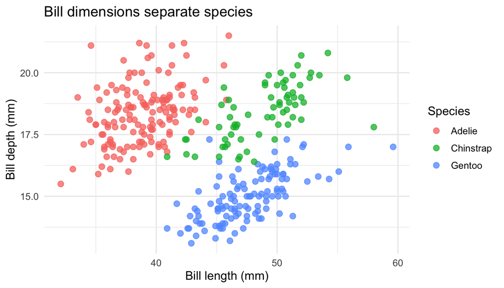

```r
ggplot(penguins_clean,
       aes(x = bill_length_mm, y = bill_depth_mm, colour = species)) +
  geom_point(alpha = 0.75, size = 2.4) +
  labs(
    title = "Bill dimensions separate species",
    x = "Bill length (mm)",
    y = "Bill depth (mm)",
    colour = "Species"
  )
```

## 1.3 Four variables: colour + shape

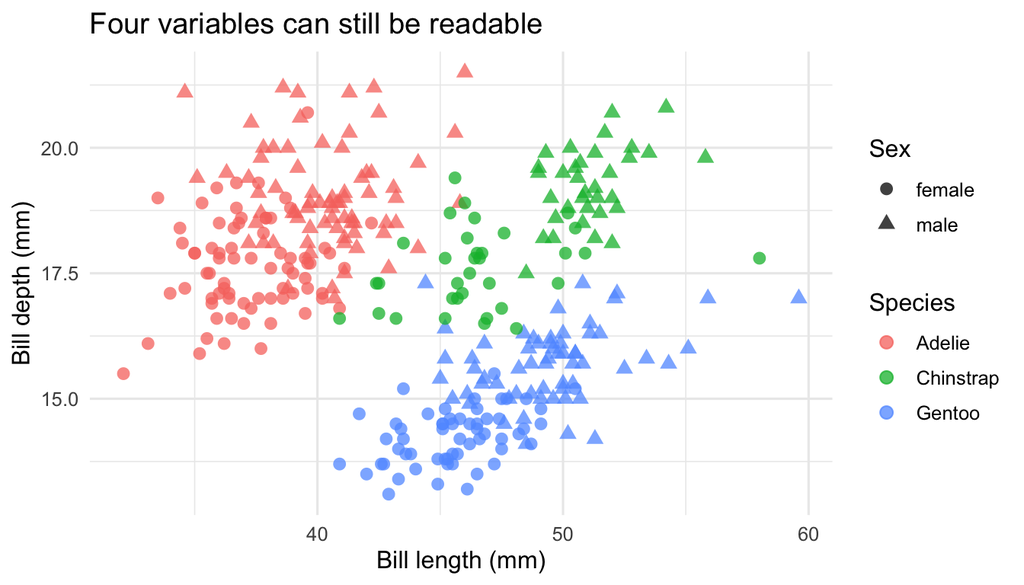

```r
ggplot(penguins_clean,
       aes(x = bill_length_mm, y = bill_depth_mm,
           colour = species, shape = sex)) +
  geom_point(alpha = 0.75, size = 2.6) +
  labs(
    title = "Four variables can still be readable",
    x = "Bill length (mm)",
    y = "Bill depth (mm)",
    colour = "Species",
    shape = "Sex"
  )
```

## 1.4 Five variables: size can become hard to read

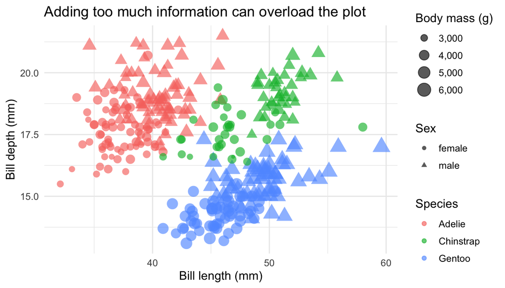

```r
ggplot(penguins_clean,
       aes(x = bill_length_mm, y = bill_depth_mm,
           colour = species, shape = sex, size = body_mass_g)) +
  geom_point(alpha = 0.65) +
  scale_size_continuous(range = c(1.5, 6), labels = comma) +
  labs(
    title = "Adding too much information can overload the plot",
    x = "Bill length (mm)",
    y = "Bill depth (mm)",
    colour = "Species",
    shape = "Sex",
    size = "Body mass (g)"
  )
```

## 1.5 Alternative: facet instead of overloading aesthetics

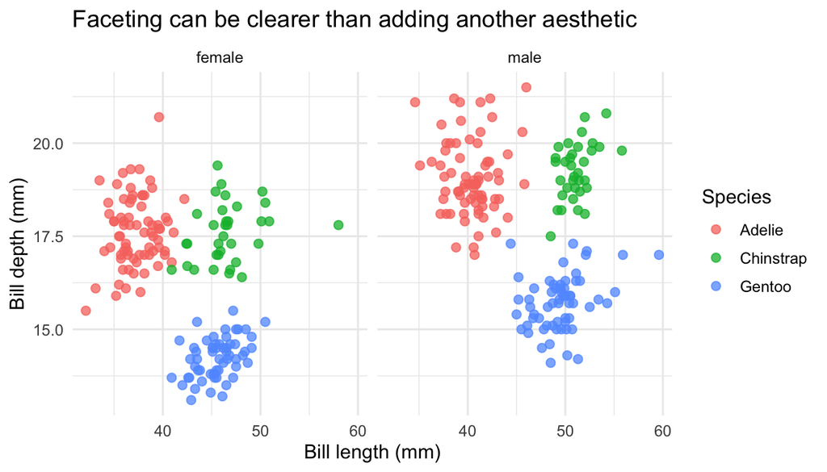

```r
ggplot(penguins_clean,
       aes(x = bill_length_mm, y = bill_depth_mm, colour = species)) +
  geom_point(alpha = 0.75, size = 2.2) +
  facet_wrap(~ sex) +
  labs(
    title = "Faceting can be clearer than adding another aesthetic",
    x = "Bill length (mm)",
    y = "Bill depth (mm)",
    colour = "Species"
  )
```

# 2 Faceting

## 2.1 `facet_wrap()`

Use `facet_wrap()` for one grouping variable with several levels.

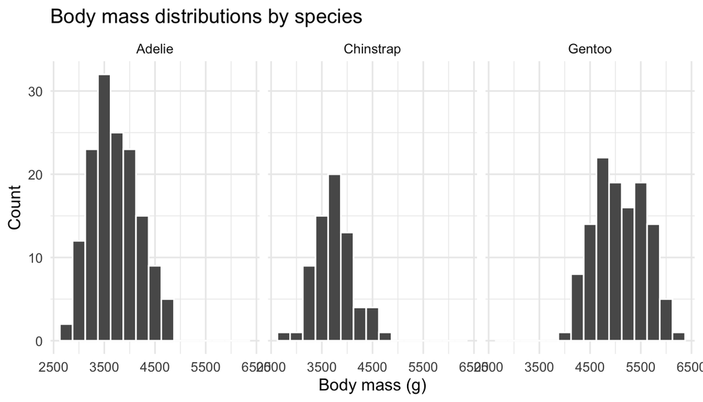

```r
ggplot(penguins_clean, aes(x = body_mass_g)) +
  geom_histogram(binwidth = 250, colour = "white") +
  facet_wrap(~ species) +
  labs(
    title = "Body mass distributions by species",
    x = "Body mass (g)",
    y = "Count"
  )
```

## 2.2 `facet_grid()`

Use `facet_grid(rows ~ columns)` when two grouping variables define a matrix.

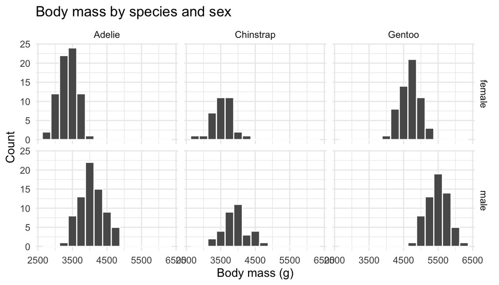

```r
ggplot(penguins_clean, aes(x = body_mass_g)) +
  geom_histogram(binwidth = 250, colour = "white") +
  facet_grid(sex ~ species) +
  labs(
    title = "Body mass by species and sex",
    x = "Body mass (g)",
    y = "Count"
  )
```

# 3 Summaries and uncertainty

## 3.1 Summarise before plotting

Many plots need one row per group before plotting.

```r
penguin_summary <- penguins_clean %>%
  group_by(species, sex) %>%
  summarise(
    mean_mass = mean(body_mass_g),
    sd_mass = sd(body_mass_g),
    n = n(),
    se_mass = sd_mass / sqrt(n),
    .groups = "drop"
  )

penguin_summary
```

| species | sex | mean_mass | sd_mass | n | se_mass |
| --- | --- | --- | --- | --- | --- |
| Adelie | female | 3368.836 | 269.3801 | 73 | 31.52856 |
| Adelie | male | 4043.493 | 346.8116 | 73 | 40.59122 |
| Chinstrap | female | 3527.206 | 285.3339 | 34 | 48.93436 |
| Chinstrap | male | 3938.971 | 362.1376 | 34 | 62.10608 |
| Gentoo | female | 4679.741 | 281.5783 | 58 | 36.97304 |
| Gentoo | male | 5484.836 | 313.1586 | 61 | 40.09585 |

## 3.2 Plot means and intervals

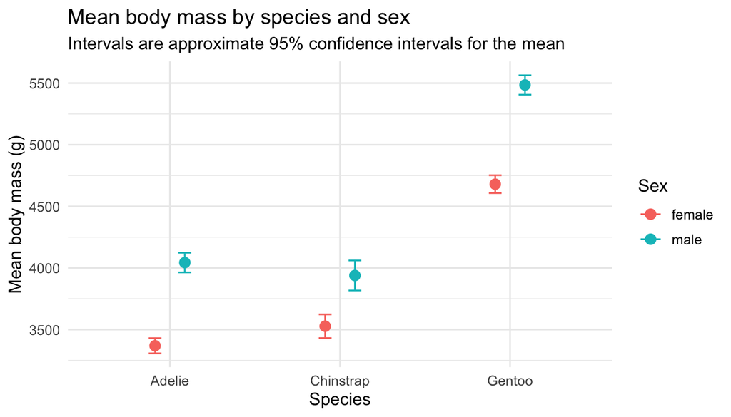

```r
ggplot(penguin_summary,
       aes(x = species, y = mean_mass, colour = sex, group = sex)) +
  geom_point(position = position_dodge(width = 0.35), size = 3) +
  geom_errorbar(aes(ymin = mean_mass - 1.96 * se_mass,
                    ymax = mean_mass + 1.96 * se_mass),
                position = position_dodge(width = 0.35),
                width = 0.15) +
  labs(
    title = "Mean body mass by species and sex",
    subtitle = "Intervals are approximate 95% confidence intervals for the mean",
    x = "Species",
    y = "Mean body mass (g)",
    colour = "Sex"
  )
```

# 4 Time-dependent graphics

## 4.1 Gapminder as a multivariate time series

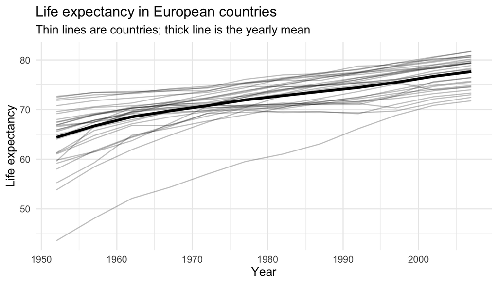

```r
gapminder %>%
  filter(continent == "Europe") %>%
  ggplot(aes(x = year, y = lifeExp, group = country)) +
  geom_line(alpha = 0.25) +
  stat_summary(aes(group = 1), fun = mean, geom = "line", linewidth = 1.3) +
  labs(
    title = "Life expectancy in European countries",
    subtitle = "Thin lines are countries; thick line is the yearly mean",
    x = "Year",
    y = "Life expectancy"
  )
```

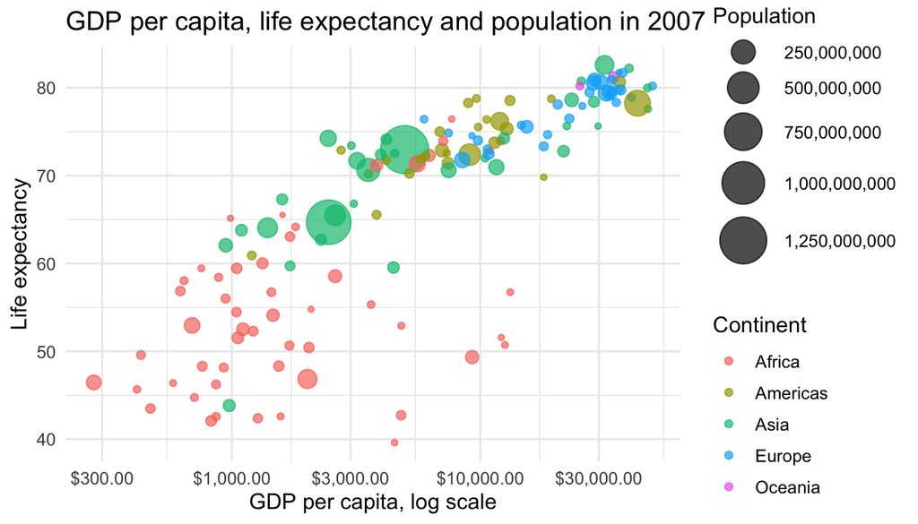

```r
gapminder %>%
  filter(year == 2007) %>%
  ggplot(aes(x = gdpPercap, y = lifeExp,
             size = pop, colour = continent)) +
  geom_point(alpha = 0.7) +
  scale_x_log10(labels = dollar) +
  scale_size_continuous(labels = comma, range = c(1, 12)) +
  labs(
    title = "GDP per capita, life expectancy and population in 2007",
    x = "GDP per capita, log scale",
    y = "Life expectancy",
    colour = "Continent",
    size = "Population"
  )
```

# 5 Maps

## 5.1 Simple point map

This example uses `maps::map_data()` to avoid requiring external shapefiles.

```r
library(maps)

world <- map_data("world")

penguin_sites <- tibble(
  island = c("Biscoe", "Dream", "Torgersen"),
  lon = c(-65.47, -64.73, -64.08),
  lat = c(-65.43, -64.73, -64.77)
)
```

## 5.2 Plot locations

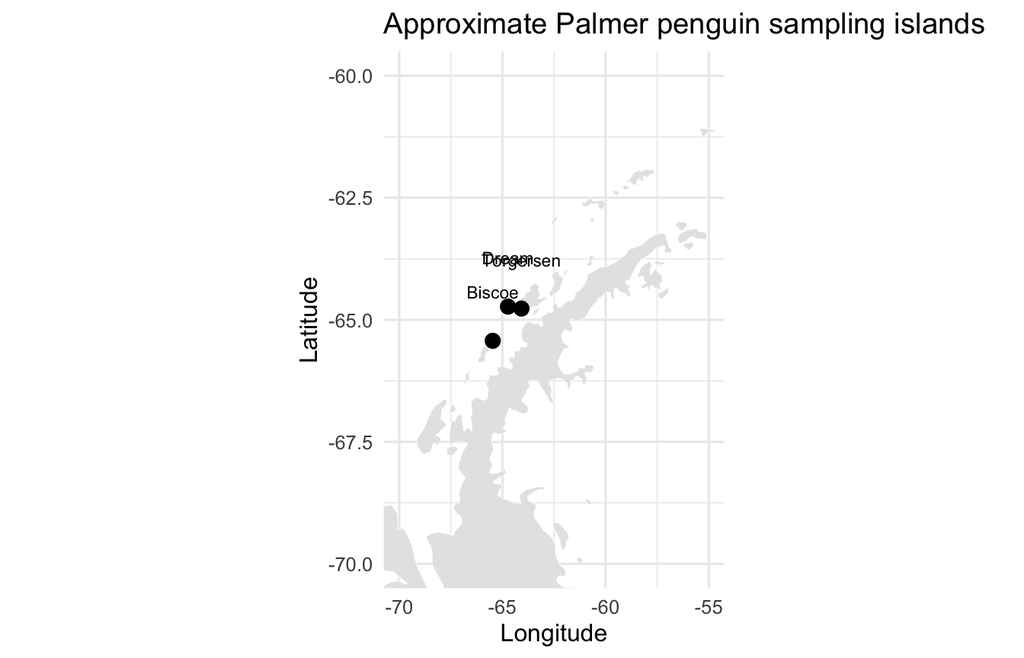

```r
ggplot() +
  geom_polygon(data = world,
               aes(x = long, y = lat, group = group),
               fill = "grey90", colour = "white", linewidth = 0.15) +
  geom_point(data = penguin_sites,
             aes(x = lon, y = lat),
             size = 3) +
  geom_text(data = penguin_sites,
            aes(x = lon, y = lat, label = island),
            nudge_y = 1, size = 3) +
  coord_quickmap(xlim = c(-70, -55), ylim = c(-70, -60)) +
  labs(
    title = "Approximate Palmer penguin sampling islands",
    x = "Longitude",
    y = "Latitude"
  )
```

## 5.3 Choropleth idea with built-in data

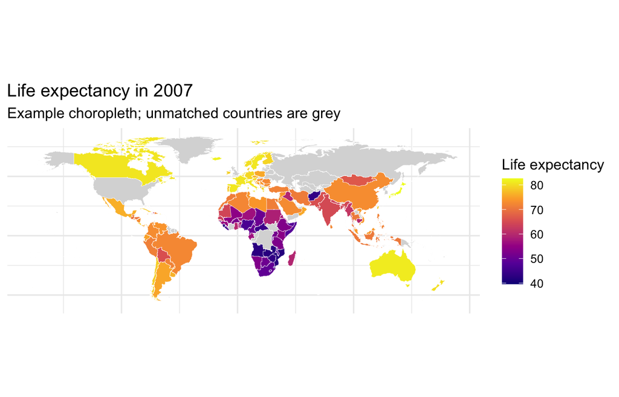

```r
world_gap <- world %>%
  filter(region != "Antarctica") %>%
  left_join(
    gapminder %>%
      filter(year == 2007) %>%
      select(region = country, lifeExp),
    by = "region"
  )

ggplot(world_gap, aes(x = long, y = lat, group = group, fill = lifeExp)) +
  geom_polygon(colour = "white", linewidth = 0.1) +
  coord_quickmap() +
  scale_fill_viridis_c(option = "C", na.value = "grey85") +
  labs(
    title = "Life expectancy in 2007",
    subtitle = "Example choropleth; unmatched countries are grey",
    x = NULL,
    y = NULL,
    fill = "Life expectancy"
  ) +
  theme(axis.text = element_blank(), axis.ticks = element_blank())
```

# 6 Model displays

## 6.1 Plot data and model together

```r
fit <- lm(body_mass_g ~ flipper_length_mm * species, data = penguins_clean)

new_penguins <- expand_grid(
  flipper_length_mm = seq(min(penguins_clean$flipper_length_mm),
                          max(penguins_clean$flipper_length_mm),
                          length.out = 80),
  species = levels(penguins_clean$species)
) %>%
  mutate(pred = predict(fit, newdata = .))
```

## 6.2 Prediction lines

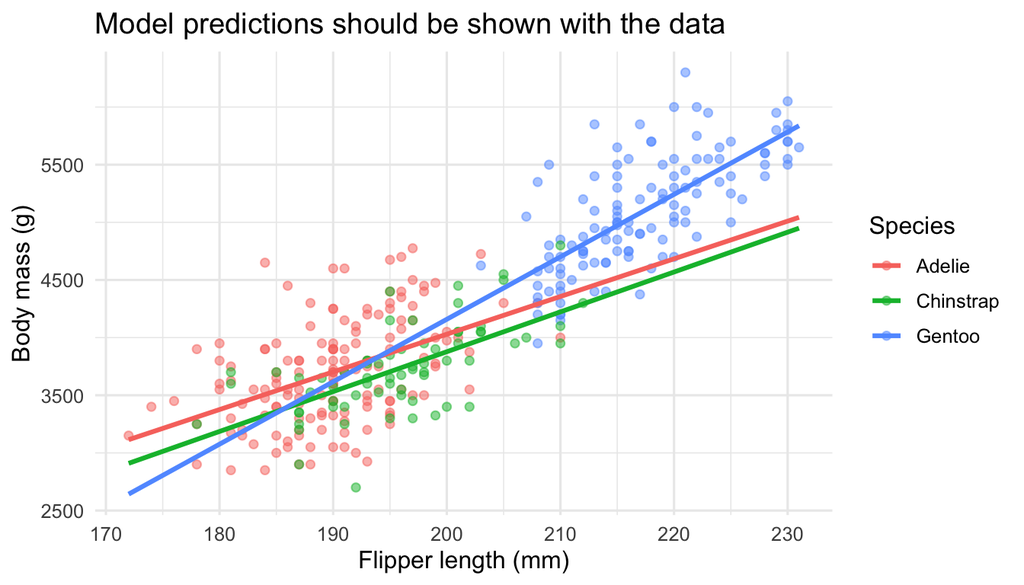

```r
ggplot(penguins_clean,
       aes(x = flipper_length_mm, y = body_mass_g, colour = species)) +
  geom_point(alpha = 0.5) +
  geom_line(data = new_penguins,
            aes(y = pred),
            linewidth = 1.1) +
  labs(
    title = "Model predictions should be shown with the data",
    x = "Flipper length (mm)",
    y = "Body mass (g)",
    colour = "Species"
  )
```

# 7 Exercises

## 7.1 Exercise 4: reduce visual overload

Create a plot using at least four variables from `penguins_clean`. Then produce a second version that uses faceting to make the same information easier to read.

### 7.1.1 one plot with several aesthetics

### 7.1.2 using facets to make the graph clearer

Questions:

- Which variables are most important?
- Which aesthetics are easiest to interpret?
- Does the plot need a legend, direct labels, or facets?

## 7.2 Exercise 5: map or time series

Choose one:

1. Use `gapminder` to create a time series for a continent of your choice.
2. Use `gapminder` and `maps` to make a choropleth for `gdpPercap` or `lifeExp`.
3. Use your own spatial data and replace the map section with `geom_sf()`.